# Getting started with R

Prof. Harbert

Lab 1

# R and RStudio

R is a programming language originally designed by statisticians. Now it is a common programming language for scientific applications.

In this course we will use R through the RStudio interface. Your instructor will demonstrate how to access and log into the RStudio server for this class.

```r
version
```

```
##                _
## platform       x86_64-pc-linux-gnu
## arch           x86_64
## os             linux-gnu
## system         x86_64, linux-gnu
## status
## major          3
## minor          6.1
## year           2019
## month          07
## day            05
## svn rev        76782
## language       R
## version.string R version 3.6.1 (2019-07-05)
## nickname       Action of the Toes
```

We can now get started with the R command promp open.

```r
x=2
print(x) ##Print method
```

```
## [1] 2
```

```r
class(x)
```

```
## [1] "numeric"
```

```r
x=seq(1:10) # Create a vector
class(x)
```

```
## [1] "integer"
```

```r
print(x)
```

```
##  [1]  1  2  3  4  5  6  7  8  9 10
```

```r
print(x[1]) # First index of vector
```

```
## [1] 1
```

```r
print(x[1:5])
```

```
## [1] 1 2 3 4 5
```

```r
y = matrix(nrow=5, ncol=5) # create a 5x5 matrix
print(y)
```

```
##      [,1] [,2] [,3] [,4] [,5]
## [1,]   NA   NA   NA   NA   NA
## [2,]   NA   NA   NA   NA   NA
## [3,]   NA   NA   NA   NA   NA
## [4,]   NA   NA   NA   NA   NA
## [5,]   NA   NA   NA   NA   NA
```

```r
class(y)
```

```
## [1] "matrix"
```

```r
y[1,1] = 5
print(y)
```

```
##      [,1] [,2] [,3] [,4] [,5]
## [1,]    5   NA   NA   NA   NA
## [2,]   NA   NA   NA   NA   NA
## [3,]   NA   NA   NA   NA   NA
## [4,]   NA   NA   NA   NA   NA
## [5,]   NA   NA   NA   NA   NA
```

```r
y[,1]= x[1:5]
print(y)
```

```
##      [,1] [,2] [,3] [,4] [,5]
## [1,]    1   NA   NA   NA   NA
## [2,]    2   NA   NA   NA   NA
## [3,]    3   NA   NA   NA   NA
## [4,]    4   NA   NA   NA   NA
## [5,]    5   NA   NA   NA   NA
```

```r
class(y[,1])
```

```
## [1] "numeric"
```

```r
y = cbind(seq(1:5),
seq(1:5),
seq(1:5),
seq(1:5),
seq(1:5))

class(y)
```

```
## [1] "matrix"
```

# Read table/tab/csv/txt text files:

read.table() read.csv() read.delim()

```r
cars = read.table('https://raw.githubusercontent.com/rsh249/bioinformatics/master/data/mtcars.csv', header=T, sep = ',') # Read a comma separated values file
head(cars)
```

|  | model | mpg | cyl | disp | hp | drat | wt | qsec | vs | am | gear | carb |
| --- | --- | --- | --- | --- | --- | --- | --- | --- | --- | --- | --- | --- |
| 1 | Mazda RX4 | 21.0 | 6 | 160 | 110 | 3.90 | 2.620 | 16.46 | 0 | 1 | 4 | 4 |
| 2 | Mazda RX4 Wag | 21.0 | 6 | 160 | 110 | 3.90 | 2.875 | 17.02 | 0 | 1 | 4 | 4 |
| 3 | Datsun 710 | 22.8 | 4 | 108 | 93 | 3.85 | 2.320 | 18.61 | 1 | 1 | 4 | 1 |
| 4 | Hornet 4 Drive | 21.4 | 6 | 258 | 110 | 3.08 | 3.215 | 19.44 | 1 | 0 | 3 | 1 |
| 5 | Hornet Sportabout | 18.7 | 8 | 360 | 175 | 3.15 | 3.440 | 17.02 | 0 | 0 | 3 | 2 |
| 6 | Valiant | 18.1 | 6 | 225 | 105 | 2.76 | 3.460 | 20.22 | 1 | 0 | 3 | 1 |

```r
cars = read.csv('https://raw.githubusercontent.com/rsh249/bioinformatics/master/data/mtcars.csv')

cars = read.delim('https://raw.githubusercontent.com/rsh249/bioinformatics/master/data/mtcars.csv', sep=',')
```

# Write Files

```r
write.table(cars, file='mtcars.tab')
write.csv(cars, file='mtcars.csv')
```

Where are these files now?

# Basic plotting

One of R’s biggest advantages is the ability to create high quality graphics in nearly any format or style. Today we will be working with the basic plotting features of R. These are good, but limited at times. Later we will take a look at the [ggplot library](https://ggplot2.tidyverse.org/). ggplot is the current ‘state of the art’ in graphics for R.

```r
cars=read.csv('mtcars.csv')
```

```r
head(cars)
```

|  | X | model | mpg | cyl | disp | hp | drat | wt | qsec | vs | am | gear | carb |
| --- | --- | --- | --- | --- | --- | --- | --- | --- | --- | --- | --- | --- | --- |
| 1 | 1 | Mazda RX4 | 21.0 | 6 | 160 | 110 | 3.90 | 2.620 | 16.46 | 0 | 1 | 4 | 4 |
| 2 | 2 | Mazda RX4 Wag | 21.0 | 6 | 160 | 110 | 3.90 | 2.875 | 17.02 | 0 | 1 | 4 | 4 |
| 3 | 3 | Datsun 710 | 22.8 | 4 | 108 | 93 | 3.85 | 2.320 | 18.61 | 1 | 1 | 4 | 1 |
| 4 | 4 | Hornet 4 Drive | 21.4 | 6 | 258 | 110 | 3.08 | 3.215 | 19.44 | 1 | 0 | 3 | 1 |
| 5 | 5 | Hornet Sportabout | 18.7 | 8 | 360 | 175 | 3.15 | 3.440 | 17.02 | 0 | 0 | 3 | 2 |
| 6 | 6 | Valiant | 18.1 | 6 | 225 | 105 | 2.76 | 3.460 | 20.22 | 1 | 0 | 3 | 1 |

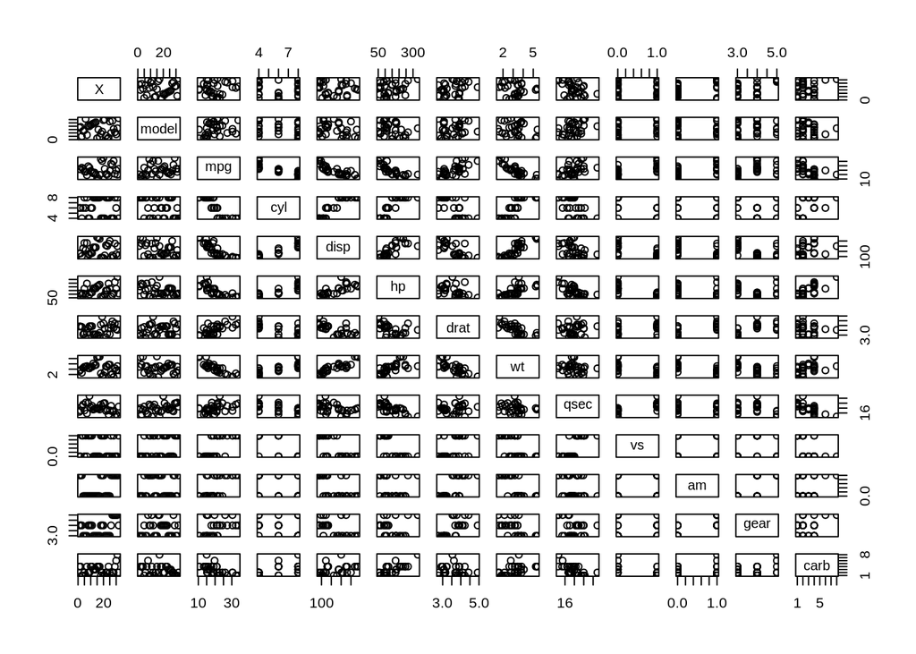

```r
plot(cars)
```

OK. That was not so great. Let’s try somethnig more useful for visualizing these data. We can tell plot() which columns we want to create a scatterplot for:

```r
colnames(cars)
```

```
##  [1] "X"     "model" "mpg"   "cyl"   "disp"  "hp"    "drat"  "wt"
##  [9] "qsec"  "vs"    "am"    "gear"  "carb"
```

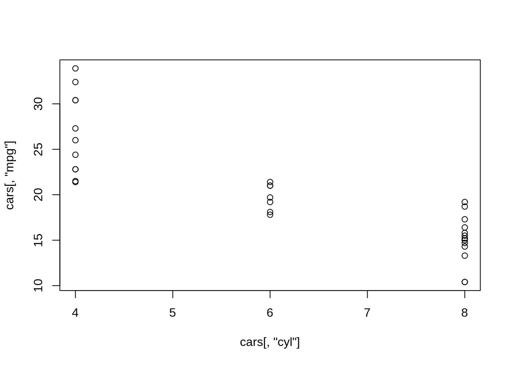

```r
plot(cars[,'cyl'], cars[,'mpg'])
```

OR we can create other types of plots by calling other functions. e.g., a histogram of boxplot:

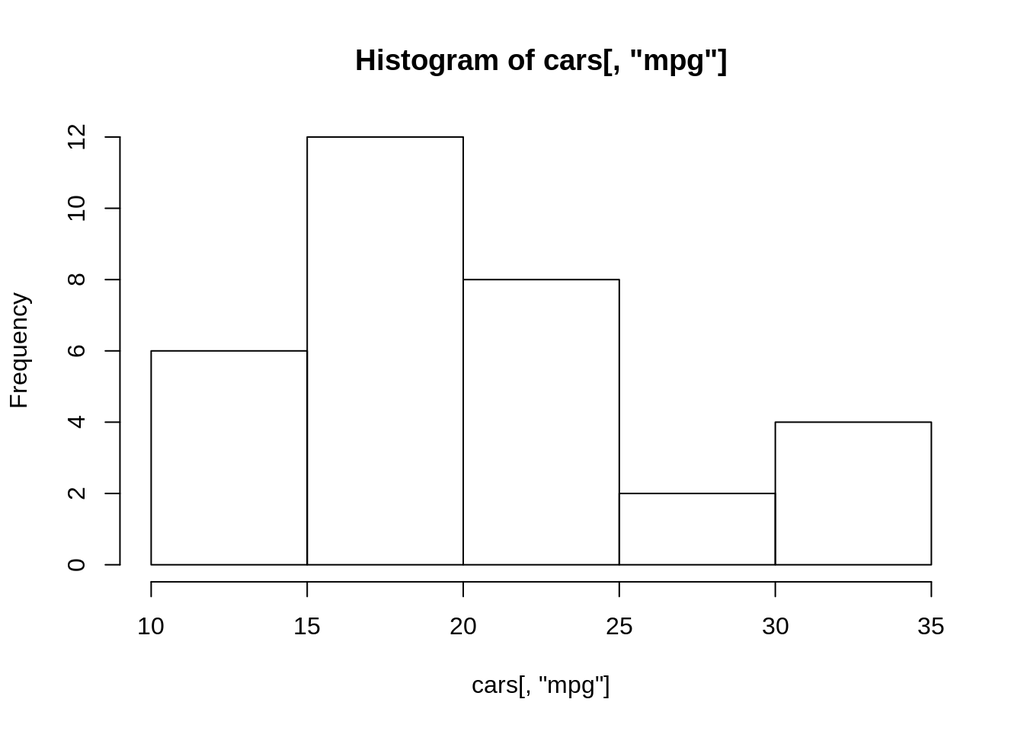

```r
hist(cars[,'mpg'])
```

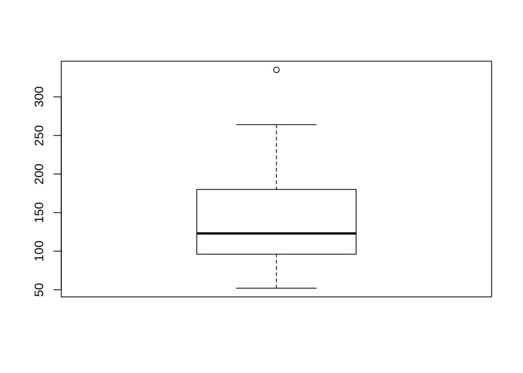

```r
boxplot(cars[,'hp'])
```

# Homework Assignment

1. Read your data into R. Create a simple plot of some of your data. Post it to the [#plots](https://introbioinformatics.slack.com/messages/CMWDBLP8R) channel.
2. *DISCUSSION*: In the slack [#discussion](https://introbioinformatics.slack.com/messages/CN3DX55M3) channel we will host this week’s discussion. Please search online for an R related resource for R beginners. This could be a book/eBook, a web tutorial, youtube video, or something else. Post what you find. Look through the resource you found and tell the group about it (what it is, how it is structured, who it is targetted to).

# [Home](https://rsh249.github.io/bioinformatics)